# How do American lifestyles affect steak preference?

Megan Mason, Gwen Hammond, and Ryan Jensen

2025-03-27

## Introduction

According to the United States Department of Agriculture, “The 2025 beef production outlook is raised by 15 million pounds from last month to 26.700 billion pounds”. We have also been importing more beef this past year, and that is expected to continue even through tariffs. These tariffs will also raise the price of beef. Because beef is a such an important commodity and prices are expected to increase soon, it is also important that we know how to prepare it so it isn’t wasted when we do have it. We want to find out if there are certain factors in the American lifestyle that correlate with how people prefer their steak prepared. This information could be valuable to steakhouses and restaurants that sell steak and are affected by the current economic environment. With prices rising, people are less likely to go out and price of ingredients will increase. Therefore, it is important for restaurants to know their clients, and if certain behaviors/lifestyles affect how customers prefer steak. Then, they would be able to cater to their clients with less wasted food and earn more money. individuals will feel that their money was well spent, and restaurants will have better business. Some potential questions that we are interested in examining are:

- How does household income affect whether individuals eat steak?
- How does age, location, and education affect how individuals like their steak prepared?
- How does drinking alcohol and smoking cigarettes influence how those prefer their steak prepared?

# The Data

This data set looks at social factors and risky behaviors that are found in the American lifestyle. The purpose of this data set is to predict how lifestyle choices correlate with how Americans like there steak. The data set contains 551 observations and has 15 variables which are mainly categorical. The data set we chose lists 12 factors that could contribute to how people prefer their steak cooked, which are listed below.

- Lottery: two hypothetical betting situations, the individual picks the one they think is the safer bet, response = A/B
- Smoke.Cigarettes: does the individual smoke cigarettes, response = yes/no
- Drink.Alcohol: does the individual drink alcohol, response = yes/no
- Gamble: does the individual gamble, response = yes/no
- Skydiving: does the individual go skydiving, response = yes/no
- Speed: does the individual speed while driving, response = yes/no
- Affair: has the individual ever cheated on their partner, response = yes/no
- Gender: how does the individual identify, response = male/female
- Age: how old is the individual, response = 18-29, 30-44, 45-60, >60
- Household.Income: what is the individual’s household income, response = 0-24,999; 25,000-49,999; 50,000-99,999; 100,999-149,999; 150,000+
- Education: What is the highest level of education individual attained, response = Less than high school degree, High school degree, Some college or Associate degree, Bachelor degree, Graduate degree
- Location: Where is the individual from, response = New England, Middle Atlantic, South Atlantic, East North Central, East South Central, West South Central, West North Central, Mountain
- There are three variables that are not explanatory:
  - RespondentID: arbitrary number, not useful for analysis
  - Prepared: How individual likes steak prepared, the response variable under question, response= rare, medium rare, medium, medium well, and well done. This is the primary response variable we are interested in exploring.
  - Consume.Steak: Does the individual consume steak, another response variable under question, though we are not as interested in this as we are in how steak is prepared.

## Cleaning the Data

- Megan started off cleaning the data by re-naming the columns so that they are easier to work with.
- Gwen created a subset of the data where missing values are excluded.
- Ryan created subsets of people who do eat steak and who don’t eat steak.

```r
#Gwen's Code
clean_steak <- steak[complete.cases(steak), ]

anyNA(clean_steak)
```

```
## [1] FALSE
```

```r
#Ryan's Code
library(tidyverse)
eat_steak <- clean_steak %>%
  filter(Consume.Steak == "Yes")

no_steak <- clean_steak %>%
  filter(Consume.Steak == "No")

# View(eat_steak)
# View(no_steak)
```

## Questions:

Some potential questions that we are interested in examining are:

- How does household income affect whether individuals eat steak?
- How does age affect how individuals like their steak prepared?
- How does drinking alcohol and smoking cigarettes influence how those prefer their steak prepared?

Megan’s Code:

```
## # A tibble: 5 × 2
## # Groups:   Prepared [5]
##   Prepared        n
##   <fct>       <int>
## 1 Rare           23
## 2 Medium rare   166
## 3 Medium        132
## 4 Medium Well    74
## 5 Well           35
```

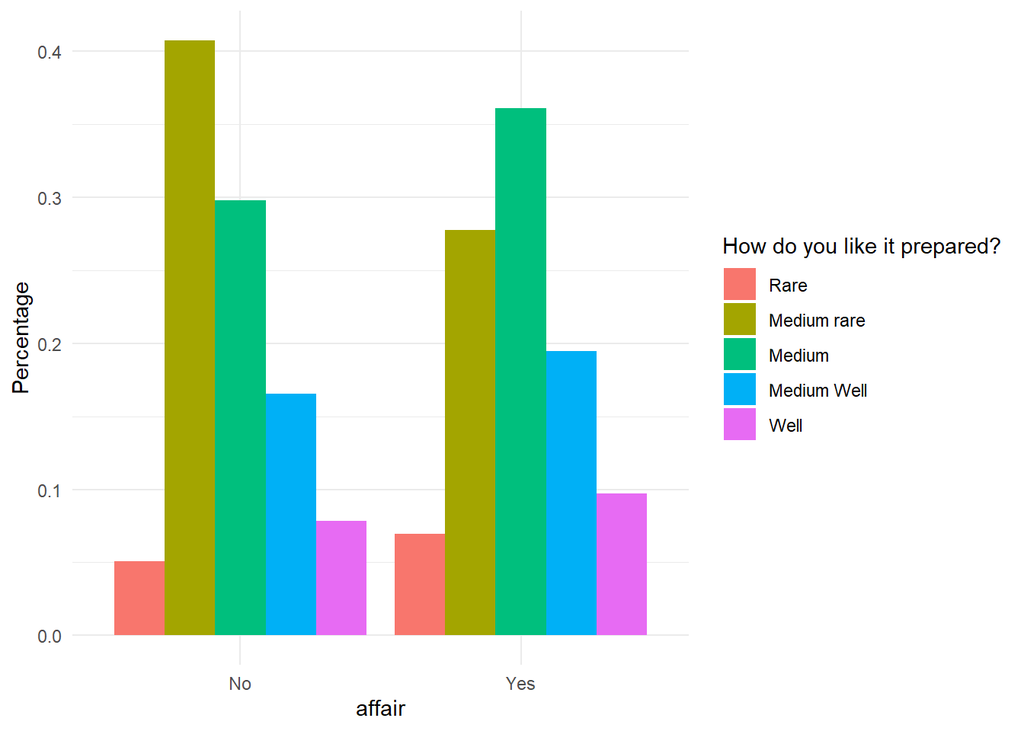

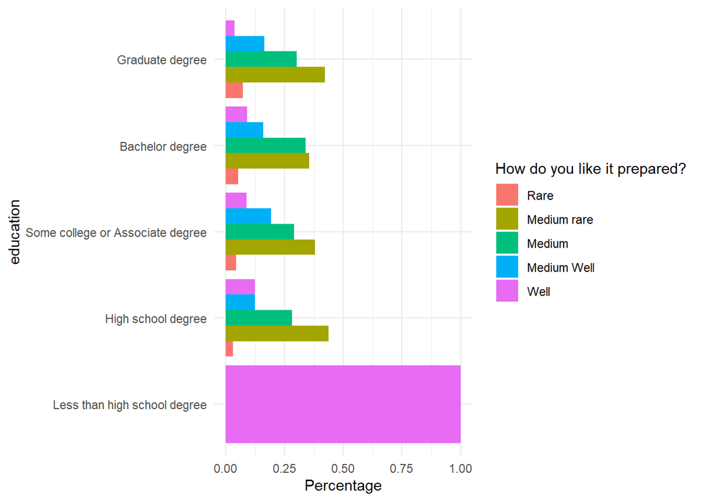

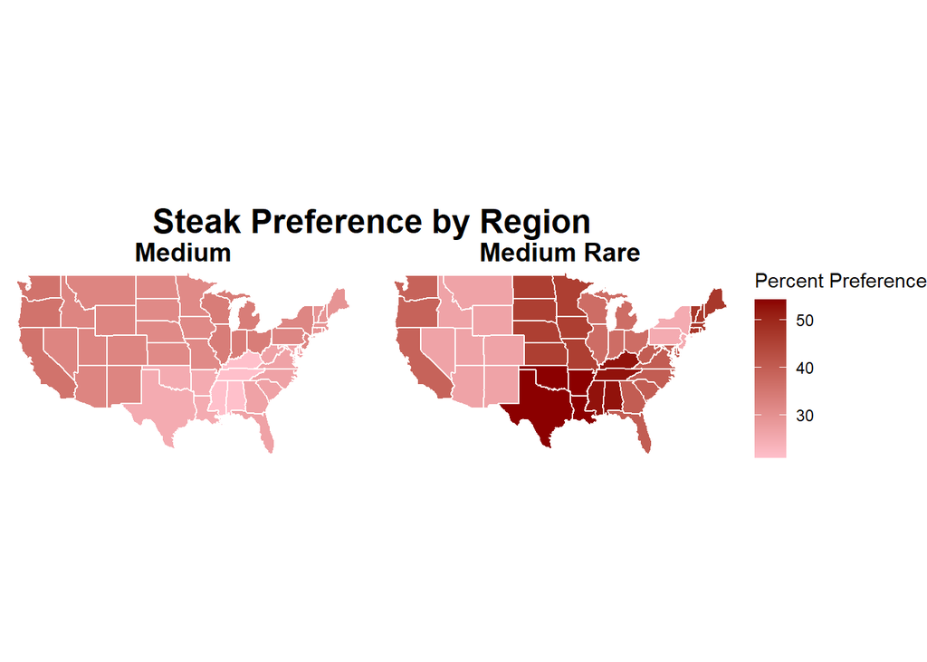

### Conclusions

- If you are opening a restaurant in the southern or midwest states, medium rare would be the best choice for preparing your steak.
- Those who have an affair are more likely to prefer steak cooked longer than those who have not had an affair.
- As the level of education increases, so does the preference for rare steak. As the level of education increases, the preference for well-done steak decreases.
- Across all responses, medium-rare is the most popular choice.

Gwen’s Code:

```r
clean_steak %>%
  filter(!is.na(Prepared) & Prepared != "") %>%
  count(Prepared, sort = TRUE)
```

```
##      Prepared   n
## 1 Medium rare 166
## 2      Medium 132
## 3 Medium Well  75
## 4        Well  36
## 5        Rare  23
```

```r
# Filter out blanks and NAs
clean_steak_filtered <- clean_steak %>%
  filter(
    !is.na(Age) & Age != "",
    !is.na(Gender) & Gender != "",
    !is.na(Gamble) & Gamble != "",
    !is.na(Consume.Steak) & Consume.Steak != ""
  )
```

- According to the code above, the most common way people like their steak prepared is Medium Rare.

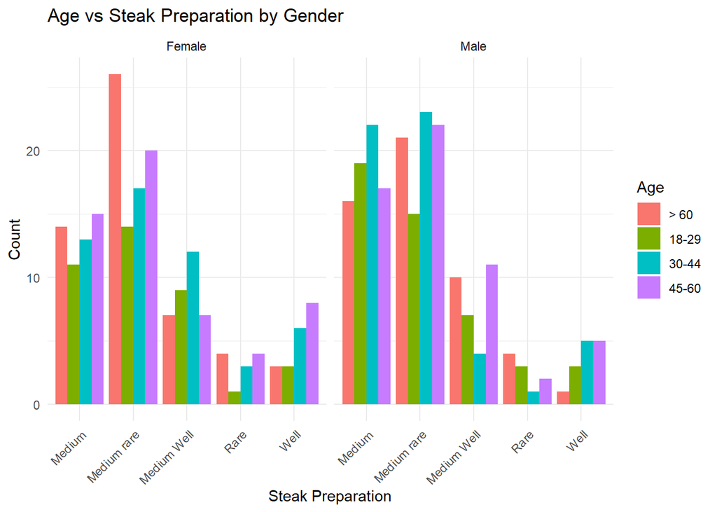

```r
#facet wrap for steak preperation by age and gender
ggplot(clean_steak_filtered %>% filter(Prepared != ""), aes(x = Prepared, fill = factor(Age))) +
  geom_bar(position = "dodge") +
  theme_minimal() +
  labs(
    title = "Age vs Steak Preparation by Gender",
    x = "Steak Preparation",
    y = "Count",
    fill = "Age"
  ) +
  facet_wrap(~ Gender) +
    theme(axis.text.x = element_text(angle = 45, hjust = 1))
```

- Upon evaluating the graph above, it can be seen that there is an overall similarity between steak preparation when sorted by age and gender. However, the graph indicates a few differences among them. For example, the graph shows that more females like their steaks well then males, and that medium and medium rare are closer in males than in females, where there is a greater difference.

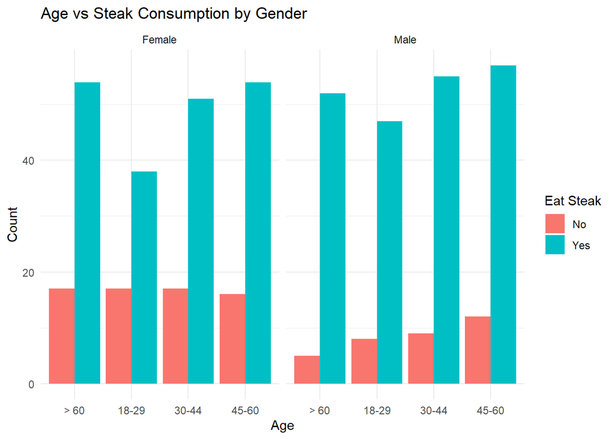

```r
# Facet Wrap: Eat Steak by Gender
ggplot(clean_steak_filtered, aes(x = factor(Age), fill = Consume.Steak)) +
  geom_bar(position = "dodge") +
  theme_minimal() +
  labs(
    title = "Age vs Steak Consumption by Gender",
    x = "Age",
    y = "Count",
    fill = "Eat Steak"
  ) +
  facet_wrap(~ Gender)
```

- The graph above shows very similar trends among age and gender versus whether or not people eat steak or not. One noticeable difference is that there are more females who do not eat steak then males who do not eat steak across all age groups.

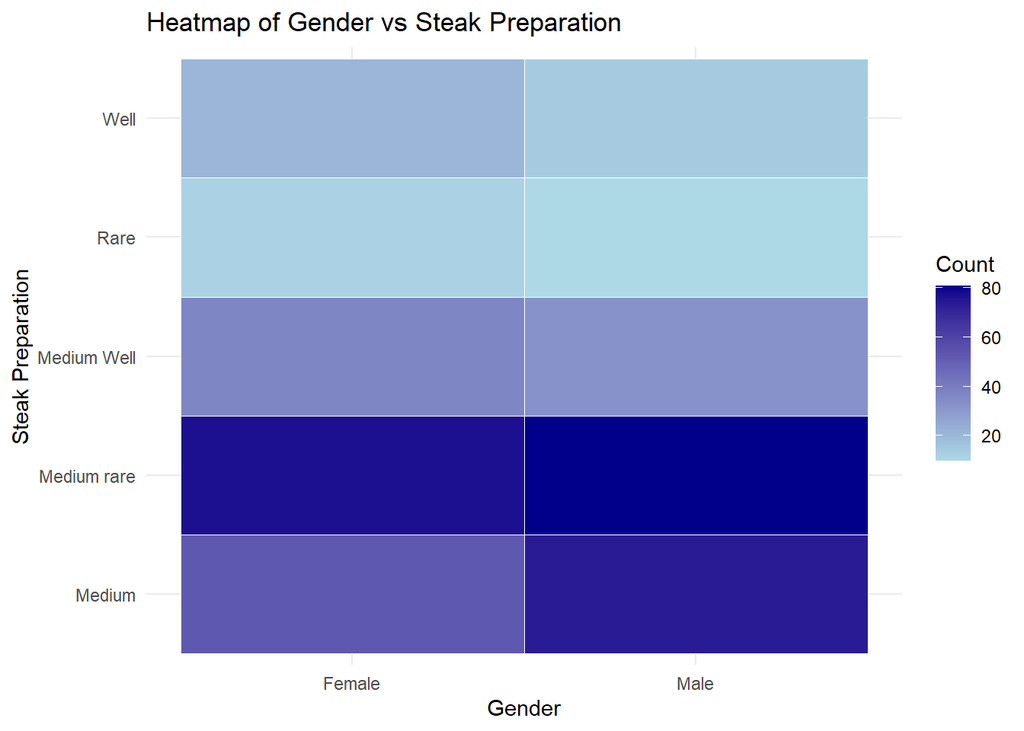

```r
# Heatmap: Gender vs Steak Preparation
clean_steak_filtered <- clean_steak %>%
  filter(!is.na(Prepared) & Prepared != "", !is.na(Gender) & Gender != "")

clean_steak_filtered %>%
  count(Gender, Prepared) %>%
  ggplot(aes(x = Gender, y = Prepared, fill = n)) +
  geom_tile(color = "white") +
  scale_fill_gradient(low = "lightblue", high = "darkblue") +
  theme_minimal() +
  labs(
    title = "Heatmap of Gender vs Steak Preparation",
    x = "Gender",
    y = "Steak Preparation",
    fill = "Count"
  )
```

- The heat map above shows that among genders, the preference for how steak is cooked is very similar. It can be seen that the biggest difference falls in the Medium category. Among males, medium is more popular than females.

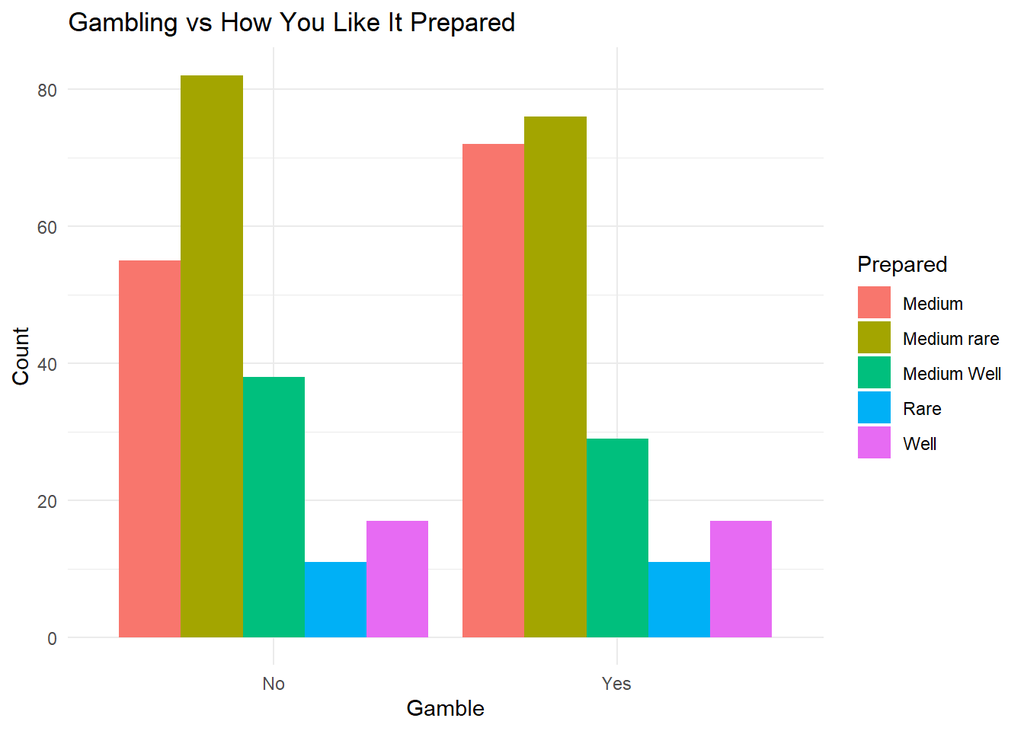

```r
# Filter out blanks and NAs
clean_steak_filtered <- clean_steak %>%
  filter(
    !is.na(Age) & Age != "",
    !is.na(Gender) & Gender != "",
    !is.na(Gamble) & Gamble != "",
    !is.na(Consume.Steak) & Consume.Steak != ""
  )

ggplot(clean_steak_filtered %>% filter(Prepared != ""), aes(x = Gamble, fill = Prepared)) +
  geom_bar(position = "dodge") +
  theme_minimal() +
  labs(
    x = "Gamble",
    y = "Count",
    fill = "Prepared",
    title = "Gambling vs How You Like It Prepared"
  )
```

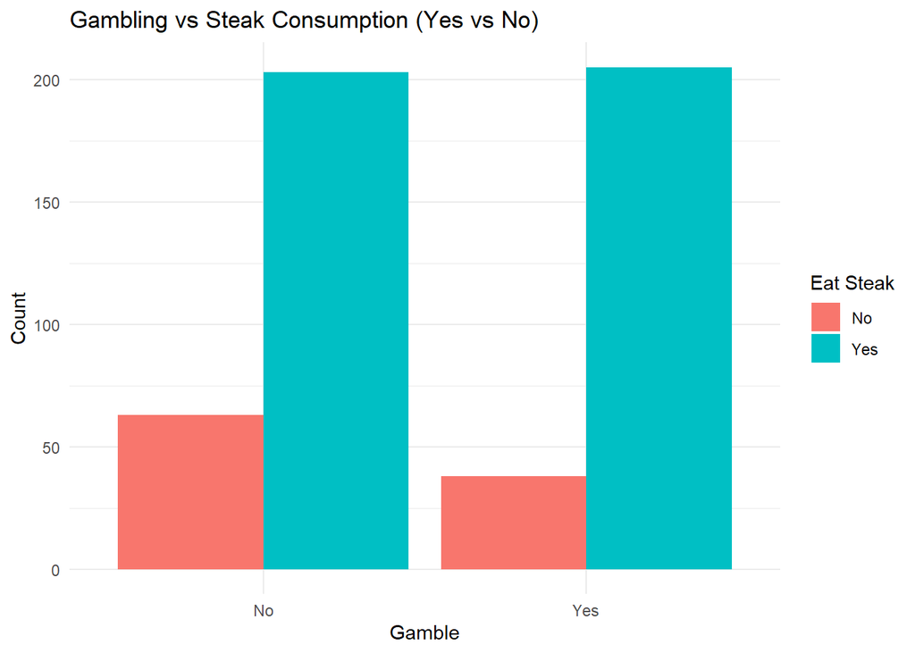

```r
ggplot(clean_steak_filtered %>% filter(Consume.Steak != ""), aes(x = Gamble, fill = Consume.Steak)) +
  geom_bar(position = "dodge") +
  theme_minimal() +
  labs(
    x = "Gamble",
    y = "Count",
    fill = "Eat Steak",
    title = "Gambling vs Steak Consumption (Yes vs No)"
  )
```

- According to the graphs above, there are not many indications that gambling affects whether or not a person eats steak or how they like their steak prepared. However, the graph of steak consumption vs gambling does show that a few more gamblers eat steak than those who do not gamble. This could be due to money situations. The graph that shows gambling vs steak preparation also shows that among gamblers, medium is closer competition to medium rare than it is among non-gamblers.

Ryan’s Code:

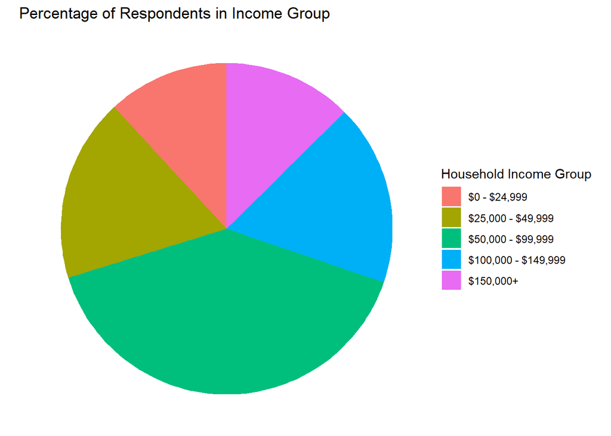

```r
noNA_Income <- clean_steak %>%
  filter(!(Household.Income == ""))
total_rows <- nrow(noNA_Income)

noNA_Income %>%
  mutate(Household.Income = factor(Household.Income, levels = c("$0 - $24,999", "$25,000 - $49,999", "$50,000 - $99,999", "$100,000 - $149,999", "$150,000+"))) %>%
  group_by(Household.Income) %>%
  summarise(
    group_percent = n() / total_rows
  ) %>%
  ggplot(aes(x = "", y = group_percent, fill = Household.Income)) +
  geom_bar(width = 1, stat = "identity") + coord_polar("y") + theme_void() + labs(title = "Percentage of Respondents in Income Group", fill = "Household Income Group")
```

- Analyzing the pie chart of the percentages of respondents in each income category, it is clear the category from $50,000-$99,999 has a much greater number of respondents then the other 4 categories. The other 4 income categories are all mostly similar in the percent of respondents in the category. This must be considered when analyzing if respondents consume steak and how they prefer it prepared within each income group.

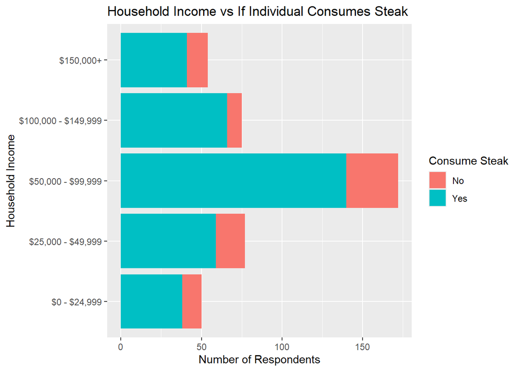

```r
clean_steak %>%
  filter(!Household.Income == "", !Consume.Steak == "") %>%
  mutate(Household.Income = factor(Household.Income, levels = c("$0 - $24,999", "$25,000 - $49,999", "$50,000 - $99,999", "$100,000 - $149,999", "$150,000+"))) %>%
  group_by(
    Household.Income, Consume.Steak
  ) %>%
  summarise(
    eat_steak = n()
  ) %>%
  ggplot(aes(x = Household.Income, y = eat_steak, fill = Consume.Steak)) + geom_col() + labs(x = "Household Income", y = "Number of Respondents", fill = "Consume Steak", title = "Household Income vs If Individual Consumes Steak") + coord_flip()
```

- There appears to be no true relationship between the household income of the individual and if they consume steak. All bars appear to have a majority of individuals who consume steak, and there appears to be no trend between the income and amount of individuals who do or do not consume steak.

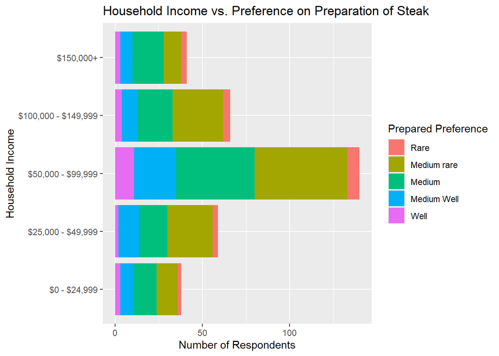

```r
eat_steak %>%
  filter(!Household.Income == "", !is.na(Prepared)) %>%
  mutate(Household.Income = factor(Household.Income, levels = c("$0 - $24,999", "$25,000 - $49,999", "$50,000 - $99,999", "$100,000 - $149,999", "$150,000+"))) %>%
  mutate(Prepared = factor(Prepared, levels = c("Rare", "Medium rare", "Medium", "Medium Well", "Well"))) %>%
  group_by(Household.Income, Prepared) %>%
  summarise(
    prepared_number = n()
  ) %>%
  ggplot(aes(x = Household.Income, y = prepared_number, fill = Prepared)) + geom_col() + coord_flip() + labs(x = "Household Income", y = "Number of Respondents", fill = "Prepared Preference", title = "Household Income vs. Preference on Preparation of Steak")
```

- The relationship between how individuals prefer their steak prepared does not appear to differ based on household income. There are some slight variations, but no overall trends that appear to stand out.

Overall it does not appear that household income affects whether and individuals eats steak and how they prefer it to be prepared.

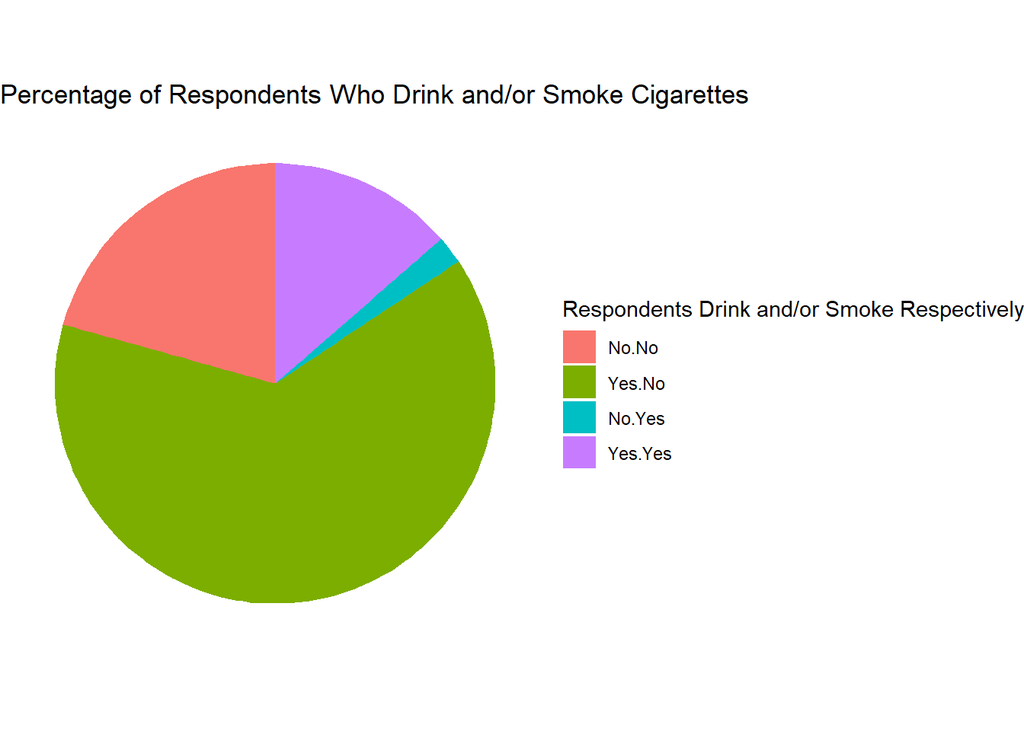

```r
noNA_alcohol_smoke <- clean_steak %>%
  filter(!Drink.Alcohol == "" & !Smoke.Cigarettes == "")
total_rows <- nrow(noNA_alcohol_smoke)

noNA_alcohol_smoke %>%
  group_by(Drink.Alcohol, Smoke.Cigarettes) %>%
  summarise(
    group_percent = n() / total_rows
  ) %>%
  ggplot(aes(x = "", y = group_percent, fill = interaction(Drink.Alcohol,Smoke.Cigarettes))) +
  geom_bar(width = 1, stat = "identity") + coord_polar("y") + theme_void() + labs(fill = "Respondents Drink and/or Smoke Respectively", title = "Percentage of Respondents Who Drink and/or Smoke Cigarettes")
```

- Looking at this summary, we can see that a greater majority of respondents reported that they drink alcohol but do not smoke. There is a very little amount of respondents who reported that they do not drink but do smoke. These differences will be considered when analyzing the relationship between whether they eat steak.

[output not shown]

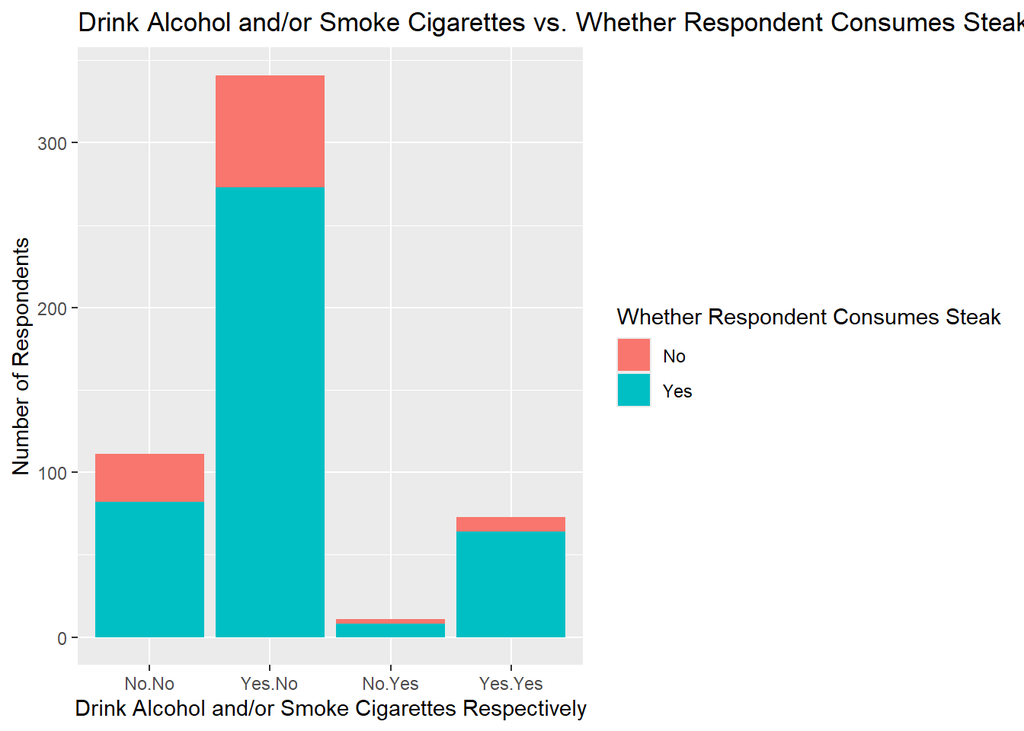

```r
noNA_alcohol_smoke %>%
  filter(!Consume.Steak == "") %>%
  group_by(Drink.Alcohol, Smoke.Cigarettes, Consume.Steak) %>%
  summarise(
    steak_count = n()
  ) %>%
  ggplot(aes(x = interaction(Drink.Alcohol,Smoke.Cigarettes), y = steak_count, fill = Consume.Steak)) + geom_col() + labs(title = "Drink Alcohol and/or Smoke Cigarettes vs. Whether Respondent Consumes Steak", x = "Drink Alcohol and/or Smoke Cigarettes Respectively", y = "Number of Respondents", fill = "Whether Respondent Consumes Steak")
```

- Analyzing the relationship between whether respondents smoke cigarettes and/or drink alcohol, there does not appear to be any major trends between the two. Respondents in all four categories tend to respond that they do consume steak.

[output not shown]

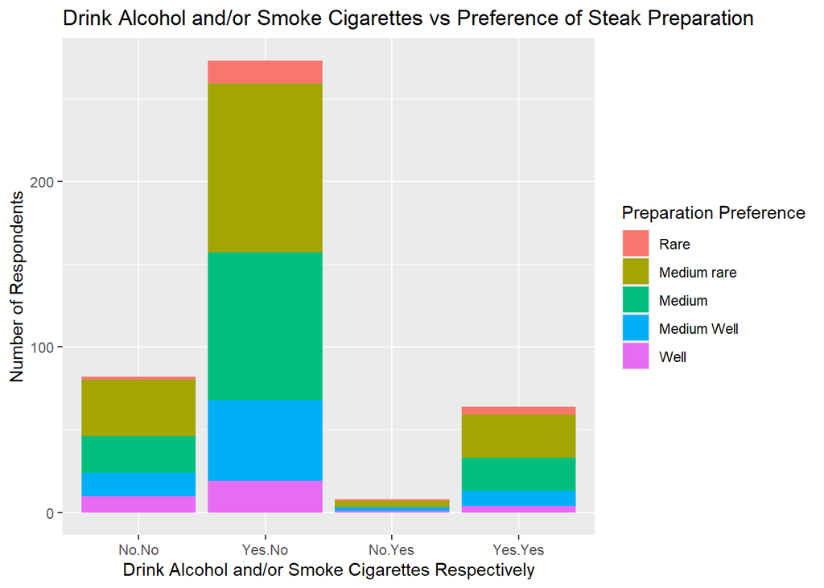

```r
noNA_alcohol_smoke %>%
  filter(!Prepared == "" & Consume.Steak == "Yes") %>%
   mutate(Prepared = factor(Prepared, levels = c("Rare", "Medium rare", "Medium", "Medium Well", "Well"))) %>%
  group_by(Drink.Alcohol, Smoke.Cigarettes, Prepared) %>%
  summarise(
    totals_Prepared = n()
  ) %>%
  ggplot(aes(x = interaction(Drink.Alcohol, Smoke.Cigarettes), y = totals_Prepared, fill = Prepared)) + geom_col() + labs(title = "Drink Alcohol and/or Smoke Cigarettes vs Preference of Steak Preparation", x = "Drink Alcohol and/or Smoke Cigarettes Respectively", y = "Number of Respondents", fill = "Preparation Preference")
```

Overall, there appears to be very slight differences between the four groups based on whether they drink alcohol and/or smoke cigarettes, and whether they respondents consume steak, and if they do, how they prefer their steak prepared.